# 对白葡萄酒质量的探索

凌伟森

2018/9/15

# 单变量绘图选择

```
## [1] 4898   12
```

```
## 'data.frame':    4898 obs. of  12 variables:
##  $ fixed.acidity       : num  7 6.3 8.1 7.2 7.2 8.1 6.2 7 6.3 8.1 ...
##  $ volatile.acidity    : num  0.27 0.3 0.28 0.23 0.23 0.28 0.32 0.27 0.3 0.22 ...
##  $ citric.acid         : num  0.36 0.34 0.4 0.32 0.32 0.4 0.16 0.36 0.34 0.43 ...
##  $ residual.sugar      : num  20.7 1.6 6.9 8.5 8.5 6.9 7 20.7 1.6 1.5 ...
##  $ chlorides           : num  0.045 0.049 0.05 0.058 0.058 0.05 0.045 0.045 0.049 0.044 ...
##  $ free.sulfur.dioxide : num  45 14 30 47 47 30 30 45 14 28 ...
##  $ total.sulfur.dioxide: num  170 132 97 186 186 97 136 170 132 129 ...
##  $ density             : num  1.001 0.994 0.995 0.996 0.996 ...
##  $ pH                  : num  3 3.3 3.26 3.19 3.19 3.26 3.18 3 3.3 3.22 ...
##  $ sulphates           : num  0.45 0.49 0.44 0.4 0.4 0.44 0.47 0.45 0.49 0.45 ...
##  $ alcohol             : num  8.8 9.5 10.1 9.9 9.9 10.1 9.6 8.8 9.5 11 ...
##  $ quality             : int  6 6 6 6 6 6 6 6 6 6 ...
```

```
##  fixed.acidity    volatile.acidity  citric.acid     residual.sugar
##  Min.   : 3.800   Min.   :0.0800   Min.   :0.0000   Min.   : 0.600
##  1st Qu.: 6.300   1st Qu.:0.2100   1st Qu.:0.2700   1st Qu.: 1.700
##  Median : 6.800   Median :0.2600   Median :0.3200   Median : 5.200
##  Mean   : 6.855   Mean   :0.2782   Mean   :0.3342   Mean   : 6.391
##  3rd Qu.: 7.300   3rd Qu.:0.3200   3rd Qu.:0.3900   3rd Qu.: 9.900
##  Max.   :14.200   Max.   :1.1000   Max.   :1.6600   Max.   :65.800
##    chlorides       free.sulfur.dioxide total.sulfur.dioxide
##  Min.   :0.00900   Min.   :  2.00      Min.   :  9.0
##  1st Qu.:0.03600   1st Qu.: 23.00      1st Qu.:108.0
##  Median :0.04300   Median : 34.00      Median :134.0
##  Mean   :0.04577   Mean   : 35.31      Mean   :138.4
##  3rd Qu.:0.05000   3rd Qu.: 46.00      3rd Qu.:167.0
##  Max.   :0.34600   Max.   :289.00      Max.   :440.0
##     density             pH          sulphates         alcohol
##  Min.   :0.9871   Min.   :2.720   Min.   :0.2200   Min.   : 8.00
##  1st Qu.:0.9917   1st Qu.:3.090   1st Qu.:0.4100   1st Qu.: 9.50
##  Median :0.9937   Median :3.180   Median :0.4700   Median :10.40
##  Mean   :0.9940   Mean   :3.188   Mean   :0.4898   Mean   :10.51
##  3rd Qu.:0.9961   3rd Qu.:3.280   3rd Qu.:0.5500   3rd Qu.:11.40
##  Max.   :1.0390   Max.   :3.820   Max.   :1.0800   Max.   :14.20
##     quality
##  Min.   :3.000
##  1st Qu.:5.000
##  Median :6.000
##  Mean   :5.878
##  3rd Qu.:6.000
##  Max.   :9.000
```

此数据集有12个变量，共4898条数据组成

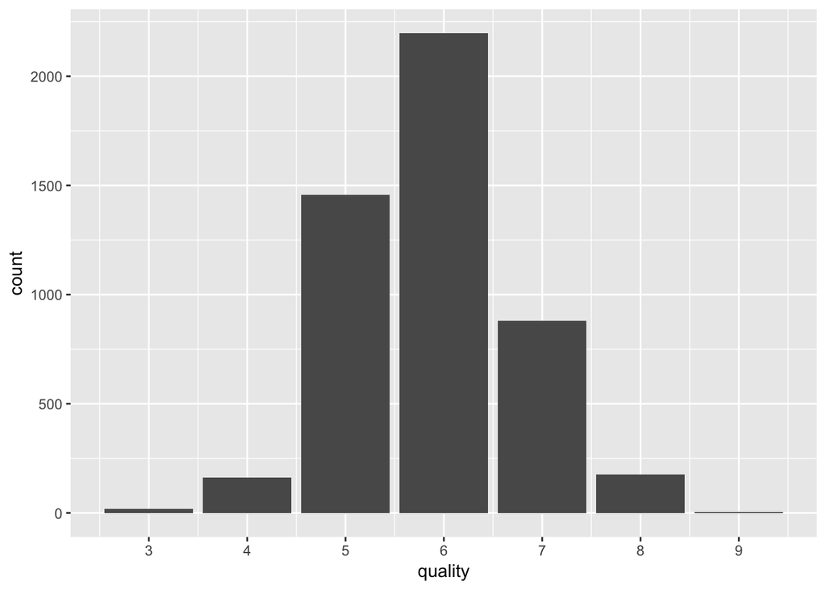

白葡萄酒的质量成正态分布，质量为6的数量最多

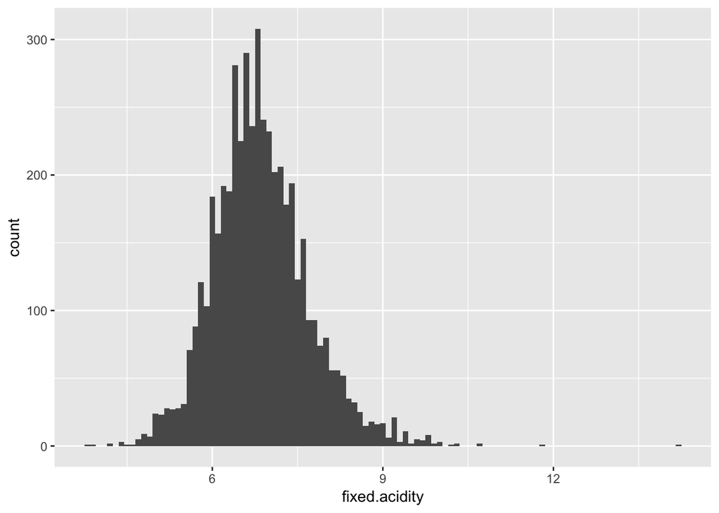

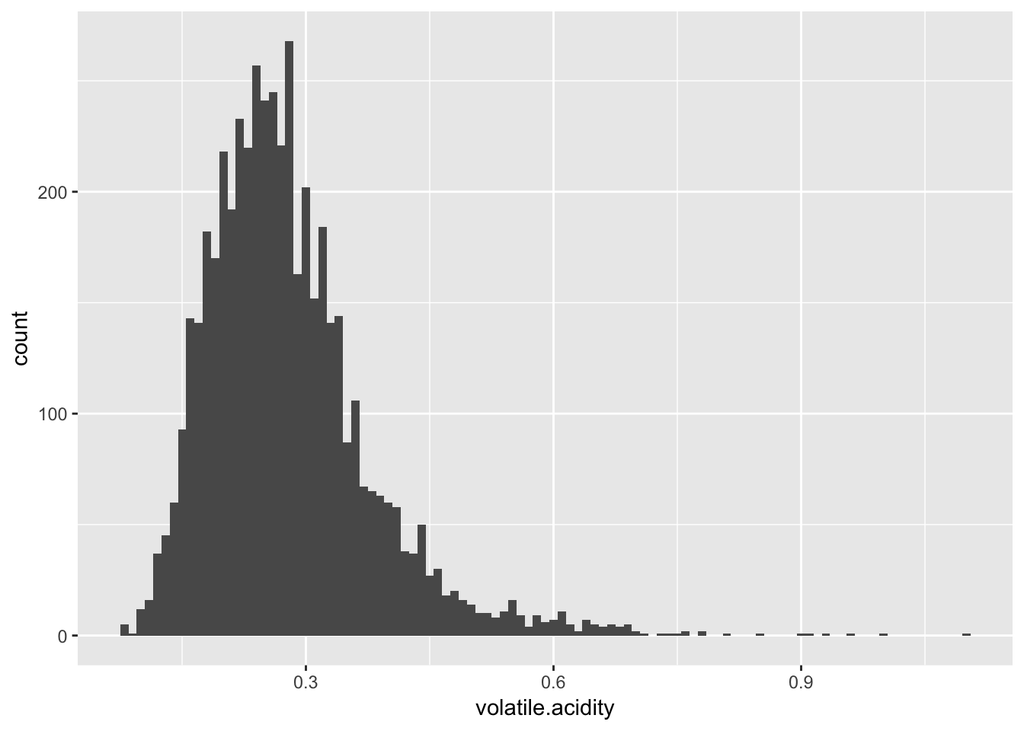

固定酸度和游离酸度都呈正偏态分布。酸度是否与pH值有关？

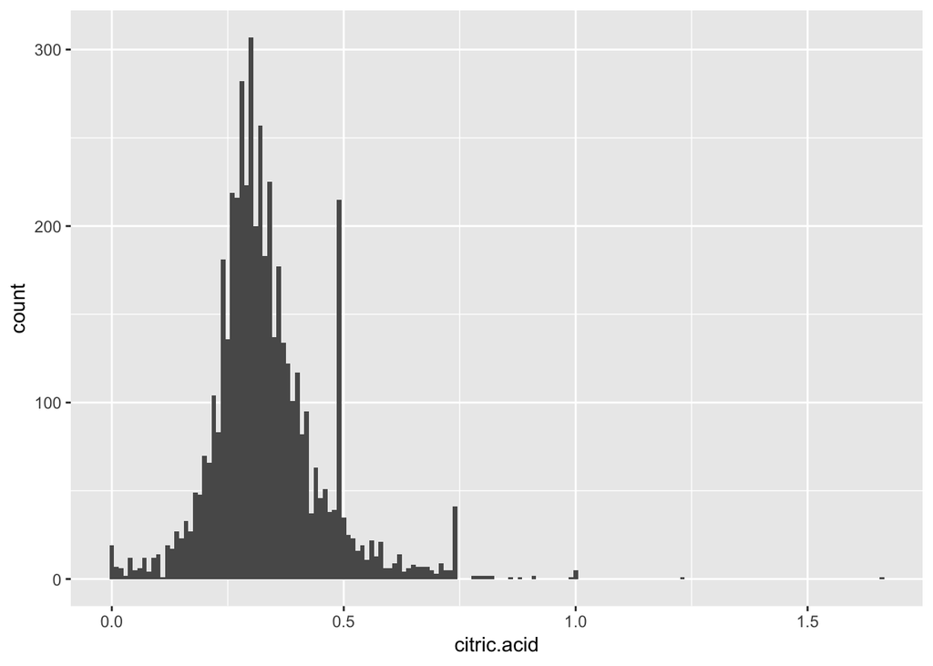

```
##    Mode   FALSE    TRUE
## logical    4879      19
```

有19份样本的柠檬酸含量为0。

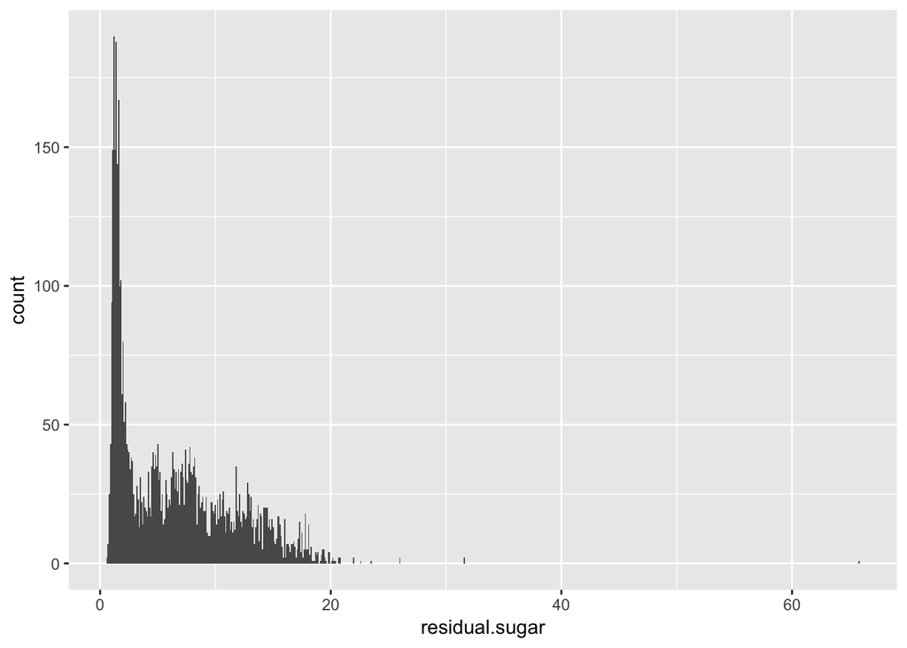

```
##    Min. 1st Qu.  Median    Mean 3rd Qu.    Max.
##   0.600   1.700   5.200   6.391   9.900  65.800
```

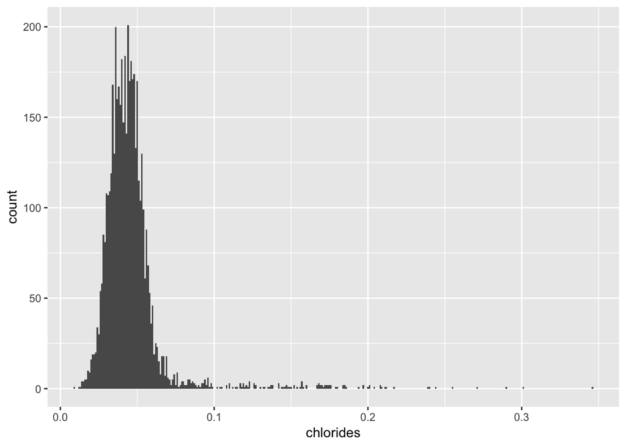

```
##    Min. 1st Qu.  Median    Mean 3rd Qu.    Max.
## 0.00900 0.03600 0.04300 0.04577 0.05000 0.34600
```

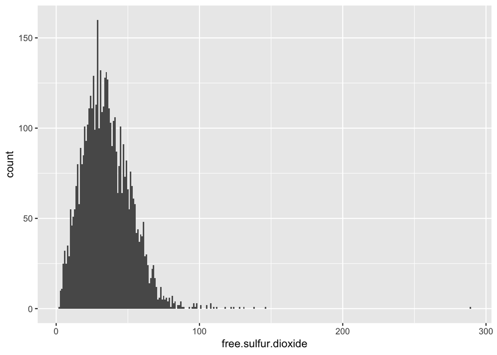

```
##    Min. 1st Qu.  Median    Mean 3rd Qu.    Max.
##    2.00   23.00   34.00   35.31   46.00  289.00
```

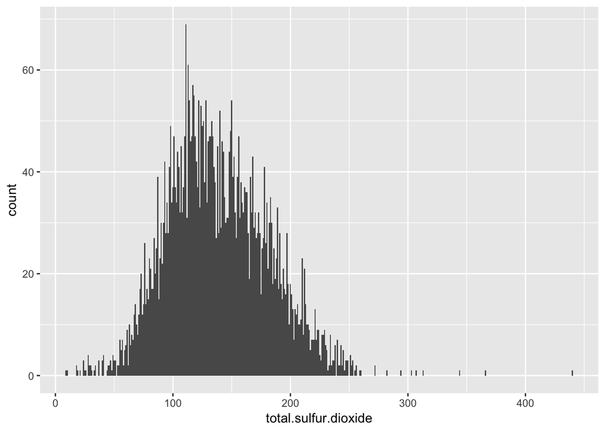

```
##    Min. 1st Qu.  Median    Mean 3rd Qu.    Max.
##     9.0   108.0   134.0   138.4   167.0   440.0
```

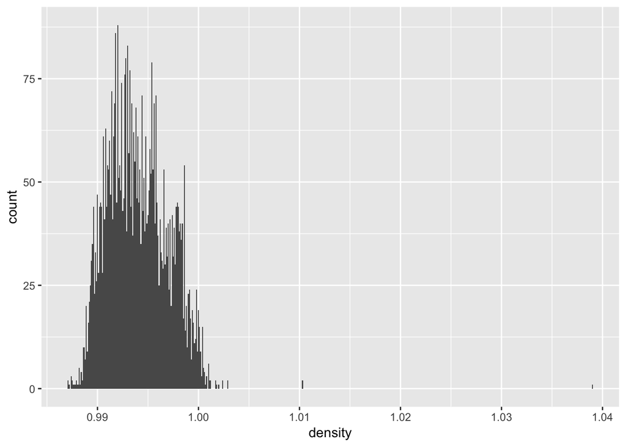

绝大部分白葡萄酒的密度在0.99g/cm<sup>3</sup>到1g/cm<sup>3</sup>之间，接近于水

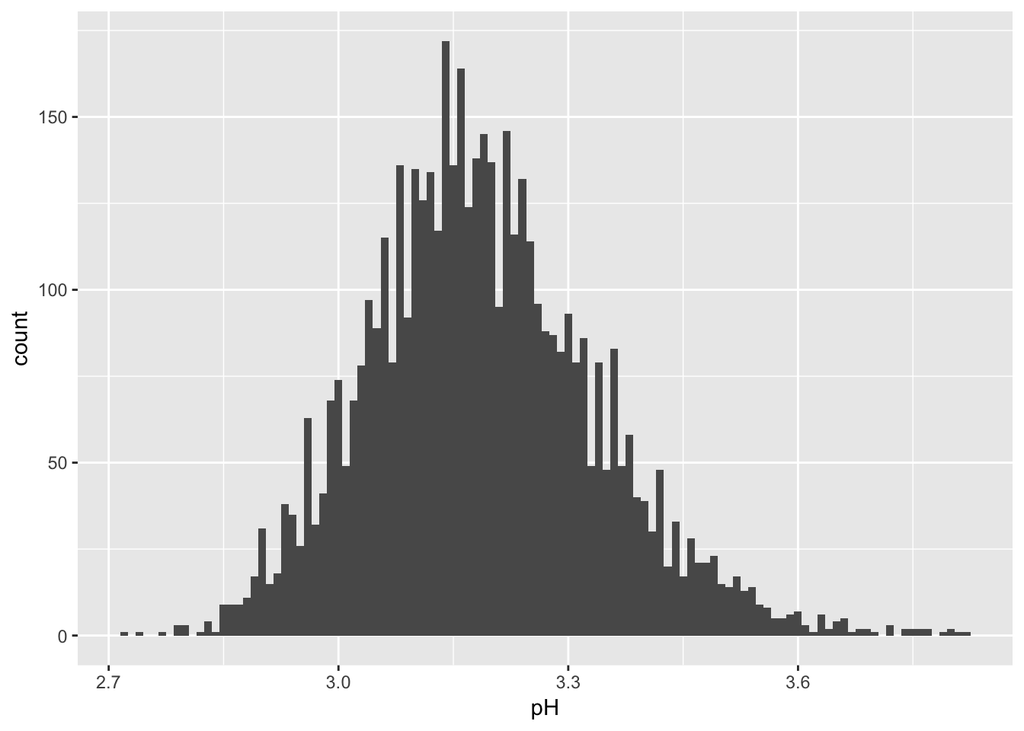

大多数白葡萄酒的pH值在3到4之间

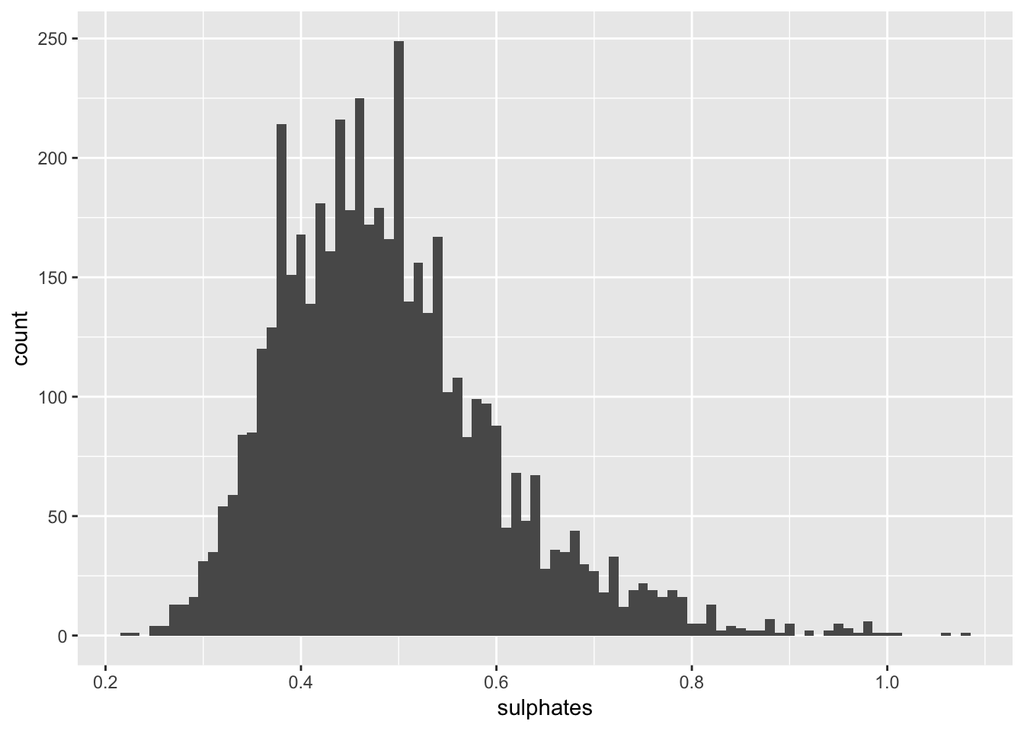

硫酸盐含量呈正态分布。

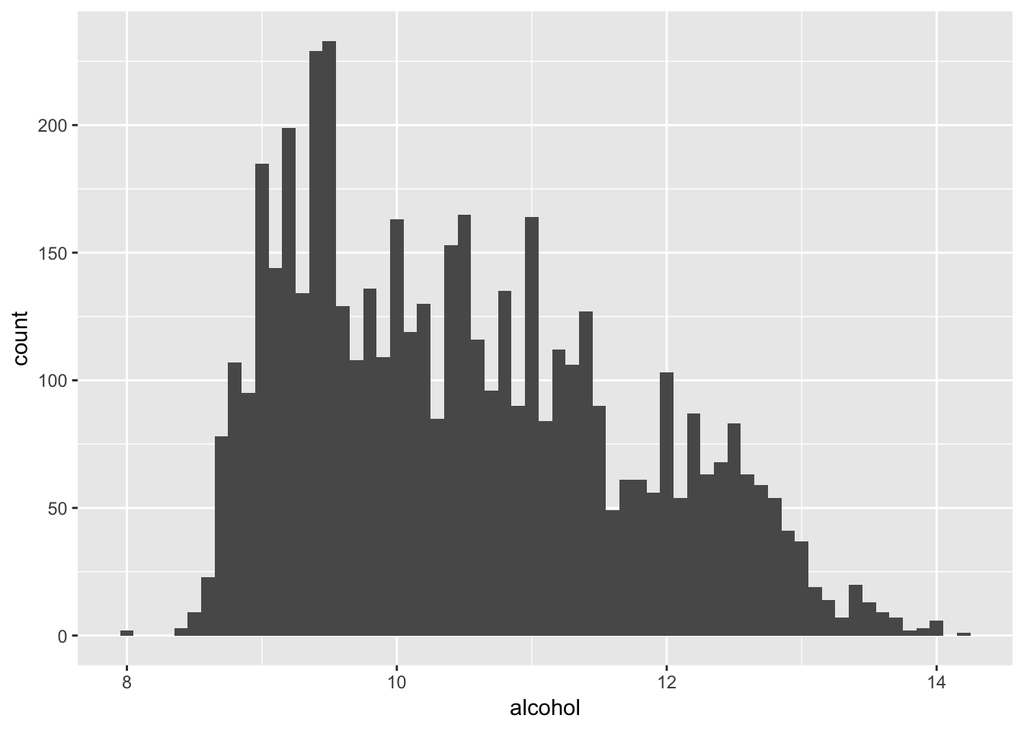

大部分白葡萄酒的酒精度在9到12之间。

# 单变量分析

### 你的数据集的结构是什么？

本数据集有4898份白葡萄酒样本组成，共有12个变量（包括：非挥发性酸度、挥发性酸度、柠檬酸、残糖、氯化物、游离二氧化硫、二氧化硫总量、密度、pH值、硫酸盐、酒精度、质量）

### 你的数据集内感兴趣的主要特性有哪些？

我对密度和酒精度与质量之间的关系比较感兴趣

### 你认为数据集内哪些其他特征可以帮助你探索兴趣特点？

残留糖属大分子结构，可能对密度会产生比较明显的影响

### 根据数据集内已有变量，你是否创建了任何新变量？

没有

### 在已经探究的特性中，是否存在任何异常分布？你是否对数据进行一些操作，如清洁、调整或改变数据的形式？如果是，你为什么会这样做？

没有

# 双变量绘图选择

```
##                      fixed.acidity volatile.acidity citric.acid
## fixed.acidity                 1.00            -0.02        0.29
## volatile.acidity             -0.02             1.00       -0.15
## citric.acid                   0.29            -0.15        1.00
## residual.sugar                0.09             0.06        0.09
## chlorides                     0.02             0.07        0.11
## free.sulfur.dioxide          -0.05            -0.10        0.09
## total.sulfur.dioxide          0.09             0.09        0.12
## density                       0.27             0.03        0.15
## pH                           -0.43            -0.03       -0.16
## sulphates                    -0.02            -0.04        0.06
## alcohol                      -0.12             0.07       -0.08
## quality                      -0.11            -0.19       -0.01
##                      residual.sugar chlorides free.sulfur.dioxide
## fixed.acidity                  0.09      0.02               -0.05
## volatile.acidity               0.06      0.07               -0.10
## citric.acid                    0.09      0.11                0.09
## residual.sugar                 1.00      0.09                0.30
## chlorides                      0.09      1.00                0.10
## free.sulfur.dioxide            0.30      0.10                1.00
## total.sulfur.dioxide           0.40      0.20                0.62
## density                        0.84      0.26                0.29
## pH                            -0.19     -0.09                0.00
## sulphates                     -0.03      0.02                0.06
## alcohol                       -0.45     -0.36               -0.25
## quality                       -0.10     -0.21                0.01
##                      total.sulfur.dioxide density    pH sulphates alcohol
## fixed.acidity                        0.09    0.27 -0.43     -0.02   -0.12
## volatile.acidity                     0.09    0.03 -0.03     -0.04    0.07
## citric.acid                          0.12    0.15 -0.16      0.06   -0.08
## residual.sugar                       0.40    0.84 -0.19     -0.03   -0.45
## chlorides                            0.20    0.26 -0.09      0.02   -0.36
## free.sulfur.dioxide                  0.62    0.29  0.00      0.06   -0.25
## total.sulfur.dioxide                 1.00    0.53  0.00      0.13   -0.45
## density                              0.53    1.00 -0.09      0.07   -0.78
## pH                                   0.00   -0.09  1.00      0.16    0.12
## sulphates                            0.13    0.07  0.16      1.00   -0.02
## alcohol                             -0.45   -0.78  0.12     -0.02    1.00
## quality                             -0.17   -0.31  0.10      0.05    0.44
##                      quality
```

[output cut: 54 more lines]

```
## alcohol              0.0000               0.0000  0.0000 0.2225
## quality              0.0000               0.0000  0.0000 0.0002    0.0000
##                      quality
## fixed.acidity        0.0000
## volatile.acidity     0.0000
## citric.acid          0.5193
## residual.sugar       0.0000
## chlorides            0.0000
## free.sulfur.dioxide  0.5681
## total.sulfur.dioxide 0.0000
## density              0.0000
## pH                   0.0000
## sulphates            0.0002
## alcohol              0.0000
## quality
```

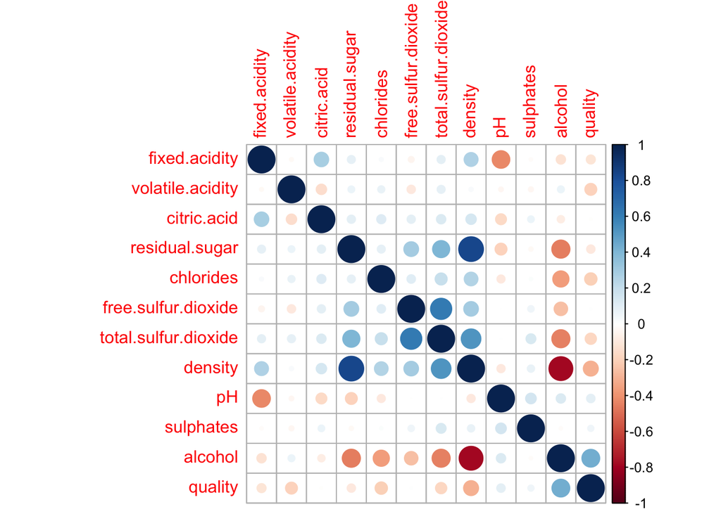

可以看出酒精度最可能对质量产生积极的影响

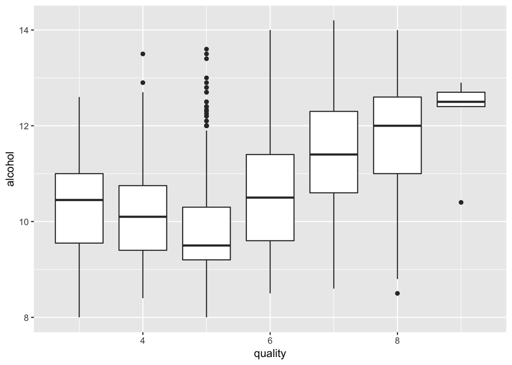

```
##
##  Pearson's product-moment correlation
##
## data:  wine_quality$quality and wine_quality$density
## t = -22.581, df = 4896, p-value < 2.2e-16
## alternative hypothesis: true correlation is not equal to 0
## 95 percent confidence interval:
##  -0.3322718 -0.2815385
## sample estimates:
##        cor
## -0.3071233
```

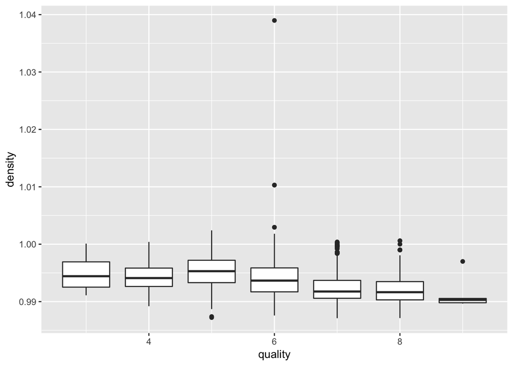

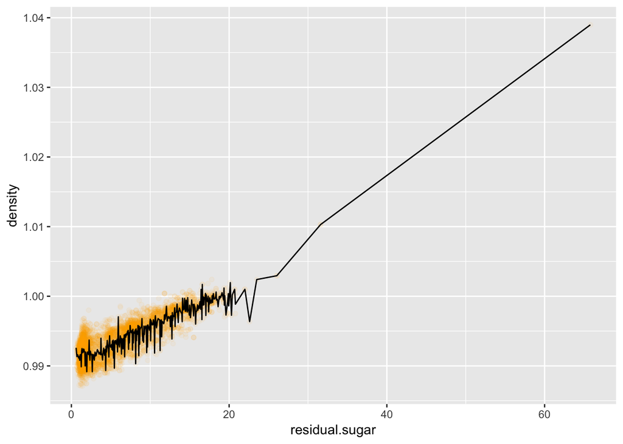

残留糖和密度有很强的正相关性

# 双变量分析

### 探讨你在这部分探究中观察到的一些关系。这些感兴趣的特性与数据集内其他特性有什么区别？

质量的类型是整数型，值的范围在3到9之间的整数，其他变量的类型是数字型

### 你是否观察到主要特性与其他特性之间的有趣关系？

酒精度对质量产生最积极的影响，大部分酒精度高的酒其质量也高

### 你发现最强的关系是什么？

残留糖和密度有最强的相关性，残留糖含量越高，密度越大

# 多变量绘图选择

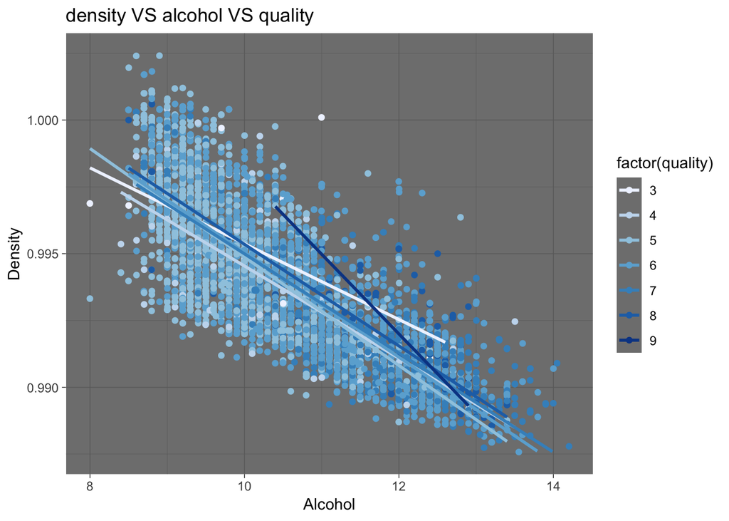

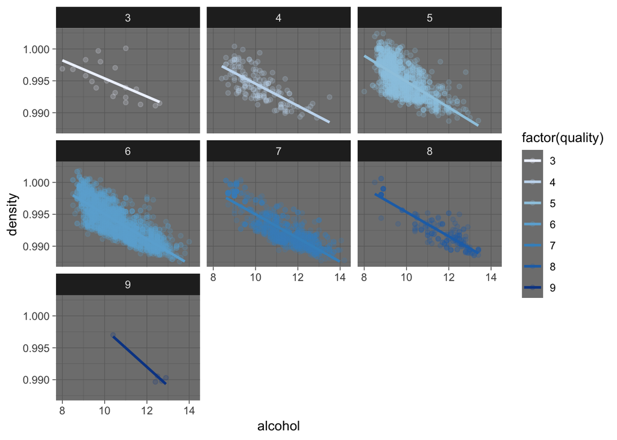

从图中可以看出对同一质量的酒，其密度与酒精度呈负相关。

# 多变量分析

### 这些特性之间是否存在有趣或惊人的联系呢？

质量为3和质量为9的酒较其他质量的酒对比，密度和酒精度分布差异较大

# 定稿图与总结

### 绘图一

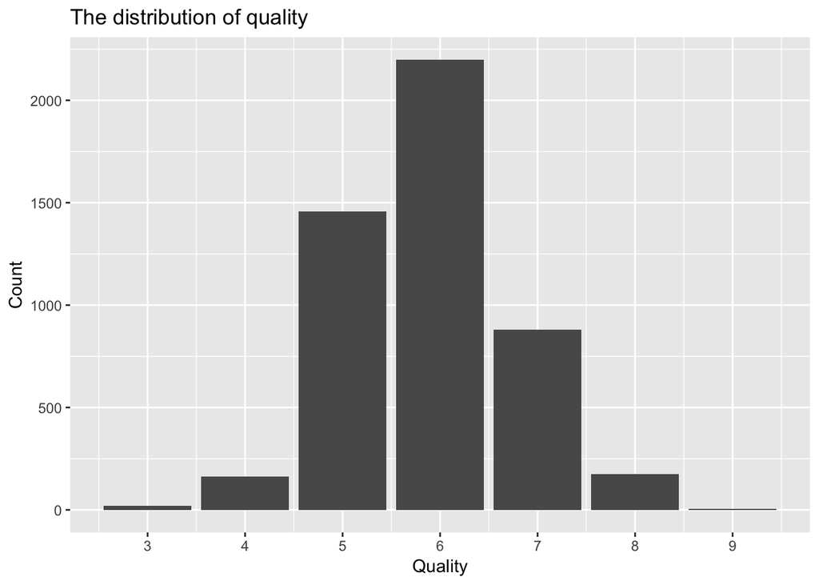

### 描述一

质量为3和9的数量最少，5-7的数量最多，质量层正态分布

### 绘图二

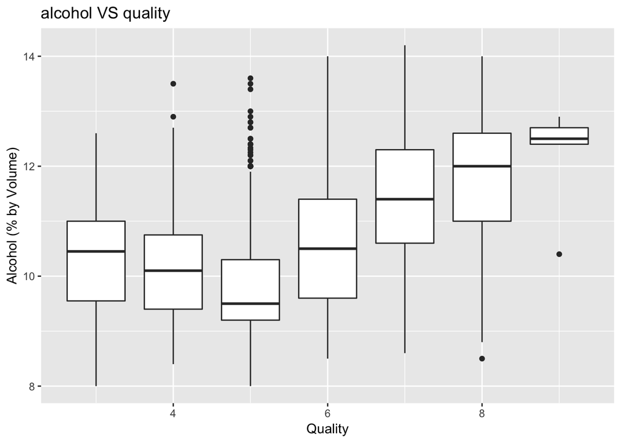

### 描述二

质量高的酒通常有较高的酒精度

### 绘图三

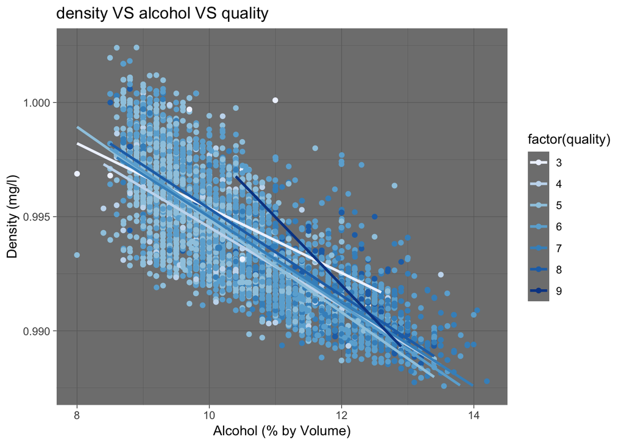

### 描述三

从图中可以看出对同一质量的酒，其密度与酒精度呈负相关。

# 反思

此数据集共包含4898条白葡萄酒数据，经过单变量、双变量和多变量分析探索后，发现密度和酒精度对质量的影响相比其他变量比较大，比较惊讶的是，pH值对质量的影响几乎没有，可能pH值要和残留糖放在一起考虑才能知道其对质量的影响，毕竟酸甜度的平衡也是影响质量的一大因素。 在分析过程中，由于质量是定序变量，对r语言语法理解不深，导致在绘图时遇到一定困难，后通过网上查询才找到解决方法。 对于本数据集，未来还可以探索酸度、残留糖和柠檬酸之间的关系，探索什么样的酸甜度的平衡会产生质量高的酒。